# Продажа квартир в Санкт-Петербурге - анализ рынка недвижимости.

### Обработка пропусков данных.

Создадим функцию, показывающую долю удалённых данных.

```python
# впоследствии этой функцией будем проверять долю удалённых данных

orig_data_len = len(data)
def check_data():
    s = orig_data_len-len(data)
    print(f'****** К этому моменту удалено {s} строк из {orig_data_len}, т.е. {round(s*100/orig_data_len)}%')

check_data()
```

```
****** К этому моменту удалено 0 строк из 23699, т.е. 0%
```

Посмотрим, в каких данных есть пропуски и по каким колонкам сколько.

```python
def lost_data(df):
    out = pd.DataFrame(columns = ['имена_колонок','пропуски','доля_потерь'])
    i = 0
    for column in df.columns:
        if df[column].isna().sum() > 0:
            out.loc[i] = [column, df[column].isna().sum(), round(df[column].isna().sum()/len(df), 4)]
            i += 1
    print(f"Пропущенные данные по колонкам, с пропусками {i} из {len(df.columns)}")
    out.set_index('имена_колонок', inplace=True)
    return out


print(lost_data(data).sort_values('доля_потерь'))
```

```
Пропущенные данные по колонкам, с пропусками 14 из 22
                     пропуски  доля_потерь
имена_колонок
locality_name              49       0.0021
floors_total               86       0.0036
living_area              1903       0.0803
kitchen_area             2278       0.0961
days_exposition          3181       0.1342
parks_around3000         5518       0.2328
ponds_around3000         5518       0.2328
cityCenters_nearest      5519       0.2329
airports_nearest         5542       0.2338
ceiling_height           9195       0.3880
balcony                 11519       0.4861
ponds_nearest           14589       0.6156
parks_nearest           15620       0.6591
is_apartment            20924       0.8829
```

Комментарий.

- ceiling_height - заполнить 39% пропусков невозможно, не будем.
- floors_total всего 86 пропусков, почти ноль, при необходимости пустые удалим.
- is_apartment - 88% его не заполняют. Логично будет заполнить пропуски как "нет" в следующем разделе.
- kitchen_area - можно предположить, что это пропуски для жилья, где кухонное пространство не выделено (не отделено), 10% выглядит правдоподобно.
- Рассчитанные Яндексом георасстояния не дополняем, пропуски от 23% до 66% - непонятно, это нормально или плохо, хорошо бы спросить у разработчиков этого софта.
- Пропуски в days_exposition посчитать не получится, т.к. нет дат снятия объявлений.
- Возможные причины незаполненности ячеек: ceiling_height считают не особо важной либо проигрышной стороной, is_apartment - заполняют по надобности, balcony - аналогично не указали, значит, балкона нет (что забыли - малореально).

### Предобработка и исправление типов данных.

```python
check_data()
```

```
****** К этому моменту удалено 0 строк из 23699, т.е. 0%
```

```python
# для ячеек is_apartment пропуски заполним False

data['is_apartment'] = data['is_apartment'].fillna(False)
data['is_apartment'].isna().sum()
```

```
0
```

```python
# для ячеек с неуказанным количеством балконов полагаем, что балконов нет, заполним нулями

data.fillna({'balcony': 0}, inplace=True)
data['balcony'].isna().sum()
```

```
0
```

```python
# если попытаться заполнить living_area (1903 пропуска) как разницу между total_area и
# kitchen_area, то минимум 1464 ячейки не заполнятся, нет смысла, оставляем как есть

((data['kitchen_area'].isna()) & (data['living_area'].isna())).sum()
```

```
1464
```

Колонка airports_nearest нам понадобится ниже для формирования графика, удалять пропуски по ней не будем, дабы не потерять 23% данных, которые могут быть полезны в других исследованиях (не про аэропорт).

```python
# floors_total - без удаления пропусков в целочисленный позже не преобразуется, потерь 0,36%,
# можно и нужно удалить. Оставлять пробовал, но как тогда float в int перевести, ведь Pandas
# NaN в колонке int хранить не умеет.

data.dropna(subset=['floors_total'], inplace=True)
```

```python
check_data()
```

```
****** К этому моменту удалено 86 строк из 23699, т.е. 0%
```

```python
# locality_name - потерь всего 49, можно и нужно удалить, иначе позже наша
# функция не сможет работать со строками, будет попадаться NaN

data.dropna(subset=['locality_name'], inplace=True)
```

```python
check_data()
```

```
****** К этому моменту удалено 134 строк из 23699, т.е. 1%
```

```python
# Переведём колонку с датой публикации из строчного в формат даты

data['first_day_exposition'] = pd.to_datetime(data['first_day_exposition'], \
                                               format='%Y-%m-%d')

print(data['first_day_exposition'].head())  # тип данных изменился на 'время'
```

```
0   2019-03-07
1   2018-12-04
2   2015-08-20
3   2015-07-24
4   2018-06-19
Name: first_day_exposition, dtype: datetime64[ns]
```

Посмотрим на интервалы для числовых колонок на предмет реально-нереально

```python
for col in data.columns:
    if data[col].dtype in ['int64', 'float64']:
        print(col, data[col].min(), data[col].max())
```

```
total_images 0 50
last_price 12190.0 763000000.0
total_area 12.0 900.0
rooms 0 19
ceiling_height 1.0 100.0
floors_total 1.0 60.0
living_area 2.0 409.7
floor 1 33
kitchen_area 1.3 112.0
balcony 0.0 5.0
airports_nearest 0.0 84869.0
cityCenters_nearest 181.0 65968.0
parks_around3000 0.0 3.0
parks_nearest 1.0 3190.0
ponds_around3000 0.0 3.0
ponds_nearest 13.0 1344.0
days_exposition 1.0 1580.0
```

Вызывают подозрение слишком маленькие размеры жилой площади 2-10 м2

```python
np.sort(data['living_area'].unique())
```

```
array([  2. ,   3. ,   5. , ..., 409. , 409.7,   nan])
```

Взглянем на те, у которых жилая площадь меньше 10, похоже у некоторых площадь кухни и жилая перепутаны.

```python
data.query('living_area < 10')[['total_area','living_area','kitchen_area']].head()
```

|  | total_area | living_area | kitchen_area |
| --- | --- | --- | --- |
| 114 | 21.4 | 8.3 | 6.3 |
| 680 | 43.0 | 9.0 | 23.0 |
| 1326 | 52.0 | 9.0 | 32.0 |
| 2309 | 62.4 | 8.4 | 41.0 |
| 3242 | 41.0 | 3.0 | 11.0 |

Для тех, где жилая < 10 и кухня > жилой, поменяем площади кухни с жилой

```python
ind = data.query('(living_area < 10) & (living_area < kitchen_area)').index
data.loc[ind,'living_area'], data.loc[ind,'kitchen_area'] = \
data.loc[ind,'kitchen_area'], data.loc[ind,'living_area']
```

```python
# Преобразуем тип floors_total , balcony float64 в 'int'

data['floors_total'] = data['floors_total'].astype(int)
data['balcony'] = data['balcony'].astype(int)
data['floors_total'].dtypes, data['balcony'].dtypes
```

```
(dtype('int32'), dtype('int32'))
```

Теперь займёмся опечатками в ceiling_height: в конце списка выводятся цифры, которые скорее всего с ошибкой в 10 раз

```python
np.sort(data['ceiling_height'].unique())[140:]
```

```
array([  3.87,   3.88,   3.9 ,   3.93,   3.95,   3.98,   4.  ,   4.06,
         4.1 ,   4.14,   4.15,   4.19,   4.2 ,   4.25,   4.3 ,   4.37,
         4.4 ,   4.45,   4.5 ,   4.65,   4.7 ,   4.8 ,   4.9 ,   5.  ,
         5.2 ,   5.3 ,   5.5 ,   5.6 ,   5.8 ,   6.  ,   8.  ,   8.3 ,
        10.3 ,  14.  ,  20.  ,  22.6 ,  24.  ,  25.  ,  26.  ,  27.  ,
        27.5 ,  32.  , 100.  ,    nan])
```

Положим, что с потолками реально ниже 2м50см жилья не продаётся, тогда все высоты более 25м поделим на 10.

```python
data['ceiling_height'] = data['ceiling_height'].where(data['ceiling_height']<25, \
                                                      data['ceiling_height']/10)
```

```python
data.drop(data.query('ceiling_height > 6').index, inplace = True)
data.query('ceiling_height > 6')['ceiling_height'].count() # проверка результата
```

```
0
```

Займёмся неявными дублями в названиях населённых пунктов. Пропуски убраны, NaN нет. К именам населённых пунктов применим замены 'ё' -'е', 'городского типа' - ''

```python
def press(c_name):
    return c_name.replace('ё','е').replace('городского типа','')

# Сформируем 2 списка, оригинальный и сжатый

names = data['locality_name'].unique()
names_compressed = []
for cty in names:
    new = press(cty)
    if new not in names_compressed:
        names_compressed.append(new)

len(names), len(names_compressed)  # посмотрим, есть ли разница в списках - 34
```

```
(364, 330)
```

```python
# Меняем имена населённых пунктов. Можно по всей колонке применить функцию press, но
# ради тренировки применим её только к тем строкам, где имена не сжаты

ind = data.query('locality_name not in @names_compressed').index
data.loc[ind,'locality_name'] = data.loc[ind,'locality_name'].apply(press)

data.query('locality_name not in @names_compressed')['locality_name'].count() # дубликатов нет
```

```
0
```

Комментарий.

- Остаётся много колонок с целыми данными и пропусками. Если приводить к типу int, то надо удалять пропуски, потому что Pandas хранит такие колонки в типе float (прочитал на stackoverflow.com, да и сам заметил, что NaN относится к типу float).
- Посмотрим позже, понадобятся ли нам именно целые числа, и вернёмся к этому вопросу при необходимости.
- Колонки floors_total , balcony из float64 перевели в тип int: так займёт меньше памяти и удобнее работать потом (в том числе на графиках).

```python
check_data()
```

```
****** К этому моменту удалено 144 строк из 23699, т.е. 1%
```

Проверим явную неправильность в этажах. Ни одно жильё не находится выше этажности своего здания.

```python
data[data['floor'] > data['floors_total']]
```

|  | total_images | last_price | total_area | first_day_exposition | rooms | ceiling_height | floors_total | living_area | floor | is_apartment | ... | kitchen_area | balcony | locality_name | airports_nearest | cityCenters_nearest | parks_around3000 | parks_nearest | ponds_around3000 | ponds_nearest | days_exposition |
| --- | --- | --- | --- | --- | --- | --- | --- | --- | --- | --- | --- | --- | --- | --- | --- | --- | --- | --- | --- | --- | --- |

0 rows × 22 columns

```python
np.sort(data['floor'].unique()) # этажности зданий в нашем дата-фрейме
```

```
array([ 1,  2,  3,  4,  5,  6,  7,  8,  9, 10, 11, 12, 13, 14, 15, 16, 17,
       18, 19, 20, 21, 22, 23, 24, 25, 26, 27, 28, 29, 30, 31, 32, 33],
      dtype=int64)
```

Посмотрим общую этажность зданий по Wiki: Лахта-центр имеет 88 этажей, есть ещё здания в 24,25,26,27,28,29,32,37,42 этажей. Наши данные не совпадают, но схожи. Пусть остаются...

Теперь проверим явную неправильность в количестве комнат, сконцентрируемся на маленьких.

```python
np.sort(data['rooms'].unique())
```

```
array([ 0,  1,  2,  3,  4,  5,  6,  7,  8,  9, 10, 11, 12, 14, 15, 16, 19],
      dtype=int64)
```

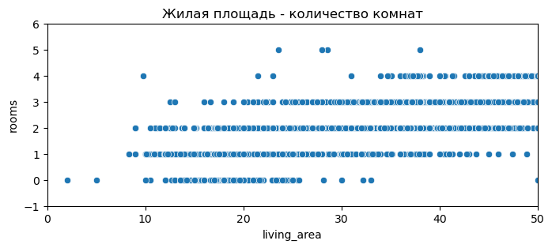

```python
plt.figure(figsize=(8,3))
plt.xlim(0, 50)
plt.ylim(-1, 6)
sns.scatterplot(x='living_area',y='rooms',data=data).set_title("Жилая площадь - количество комнат");
```

Питерцы, конечно, не японцы, но сильных аномалий не видно, и тем не менее ради тренировки положим, что средняя площадь комнаты не может быть < 6, (например, 10 + чулан/кладовка 2 = средняя 6, такое не исключено), "нарушителей" из датафрейма удалим.

```python
print(data.query('living_area/rooms < 6')['living_area'].count())  # было 16
data = data.drop(data.query('living_area/rooms < 6').index)
print(data.query('living_area/rooms < 6')['living_area'].count())  # осталось 0
```

```
16
0
```

```python
check_data()
```

```
****** К этому моменту удалено 160 строк из 23699, т.е. 1%
```

```python
# повторно выведем информацию о пропусках и посмотрим результаты проделанной работы

print(lost_data(data).sort_values('доля_потерь'))
```

```
Пропущенные данные по колонкам, с пропусками 10 из 22
                     пропуски  доля_потерь
имена_колонок
living_area              1865       0.0792
kitchen_area             2219       0.0943
days_exposition          3170       0.1347
cityCenters_nearest      5497       0.2335
parks_around3000         5496       0.2335
ponds_around3000         5496       0.2335
airports_nearest         5520       0.2345
ceiling_height           9076       0.3856
ponds_nearest           14515       0.6166
parks_nearest           15521       0.6594
```

Замечание.

- После предобработки и удаления строк с пропусками заметно, как съёживаются данные и снижается количество неявных дублей - т.е. "некачественные" данные некачественны по нескольким критериям.
- Удаление строк с пропусками выполнялось "задним числом" по потребностям графиков и анализа. Изначально задачи затереть всё, где есть пропуски, не стояло.

### Добавление в таблицу новых столбцов с расчётными данными.

```python
# Добавим в таблицу столбец с ценой за 1 кв.метр, разброс цен получается огромный

data['price_1m2'] = data['last_price'] / data['total_area']
print(round(data['price_1m2'].min(), 2), round(data['price_1m2'].max(), 2)) # разброс за метр
```

```
111.83 1907500.0
```

```python
# Добавим в таблицу столбец с днём недели публикации объявления (0 — понедельник,
# 1 — вторник и так далее).

data['week_day'] = pd.DatetimeIndex(data['first_day_exposition']).dayofweek
data['week_day'].nunique() # проверяем, получилось всего 7 дней
```

```
7
```

```python
# Добавим в таблицу столбец с месяцем публикации объявления

data['month'] = pd.DatetimeIndex(data['first_day_exposition']).month
```

```python
# Добавим в таблицу столбец с годом публикации объявления

data['year'] = pd.DatetimeIndex(data['first_day_exposition']).year
```

```python
# Добавим в таблицу столбец с типом этажа квартиры (значения — «первый», «последний», «другой»)

data['floor_type'] = data.apply(lambda x: '1-первый' if x['floor'] == 1  else \
('3-последний' if x['floor']==x['floors_total']  else '2-другой'), axis=1)
data['floor_type'].unique()   # проверяем, какие типы этажности есть в нашей колонке

# Эту же задачу можно решить методом where за 3 прохода (в 3 строки): сначала для верхних
# этажей, потом для неверхних, и в конце для первых.
```

```
array(['2-другой', '1-первый', '3-последний'], dtype=object)
```

```python
# Добавим в таблицу столбец с расстоянием до центра города в километрах
# (переведём из м в км и округлим до целых значений)

# data['center_dist'] = round(data['cityCenters_nearest']/1000,0).astype(int) - в типе int нельзя хранить NaN
data['center_dist'] = round(data['cityCenters_nearest']/1000,0)
data['center_dist'].isna().sum()  # убедимся, что пропусков 5497 (как и посчитано в начале)
```

```
5497
```

## Постороение графиков и их анализ.

### Гистограммы по основным параметрам продаваемых объектов.

#### Общая площадь обекта.

Ниже сформируем требуемые заданием графики.

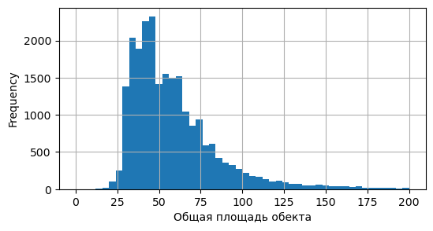

```python
plt.rcParams['figure.figsize'] = [6, 3]
plt.xlabel('Общая площадь обекта')
data['total_area'].plot(kind='hist',bins=50,range=(0,200),grid=True);
```

- Пик приходится на 45кв.м, затем до 65кв.м идёт "плато", далее нормальный, плавный спад.

#### Жилая площадь обекта.

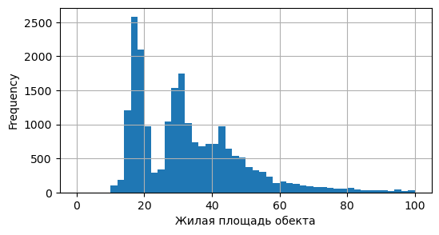

```python
plt.xlabel('Жилая площадь обекта')
data['living_area'].plot(kind='hist',bins=50,range=(0,100),grid=True);
```

- Имеется резкий пик в районе 17кв.м. Второй пик в районе 30-32кв.м. Получается, что жилая площадь в 25кв.м - относительная редкость.

#### Площадь кухни.

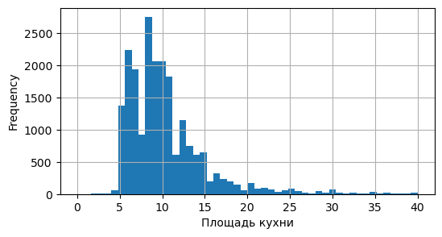

```python
plt.xlabel('Площадь кухни')
data['kitchen_area'].plot(kind='hist',bins=50,range=(0,40),grid=True);
```

- Площади кухни распределены с провалами в районе 7 и 12кв.м, в районе 8кв.м - пик.

#### Цены объектов - до 70млн.

```
763000000.0
```

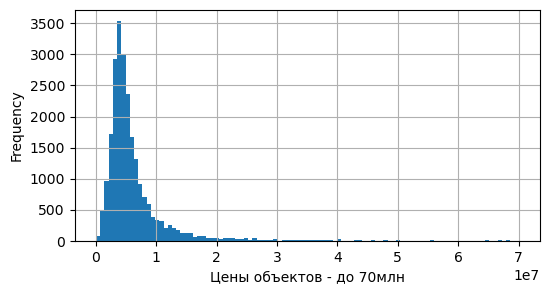

```python
plt.xlabel('Цены объектов - до 70млн')
data['last_price'].plot(kind='hist',bins=100,range=(0,70000000),grid=True)
data['last_price'].max()
```

- Для обектов до 70млн диаграмма имеет классический вид, достаточно плавная с длинным хвостом.

#### Цены объектов - от 70млн.

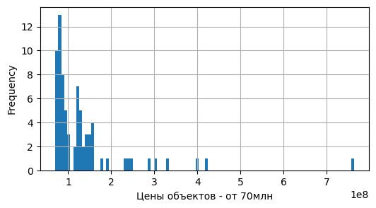

```python
plt.xlabel('Цены объектов - от 70млн')
data['last_price'].plot(kind='hist',bins=100,range=(70000000,763000000),grid=True);
```

- Для сверхдорогих обектов также заметен плавный спад, но закономерно, что больше пропусков и немонотонностей, а после 200млн предложения единичны.

#### Количество комнат.

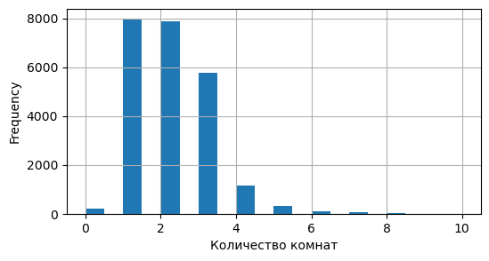

```python
plt.xlabel('Количество комнат')
data['rooms'].plot(kind='hist',bins=20,range=(0,10),grid=True);
```

- Оказывается, на рынке существует понятие "0 комнат". Пусть немного, но предлагаются квартиры с открытой планировкой, а также "студии".
- Высота столбцов показывает, что 1- и 2-комнатные квартиры продаются чаще всего, 3-хкомнатные слегка отстают. Каких-то выбросов или аномалий на гистограмме не заметно.

#### Высота потолков.

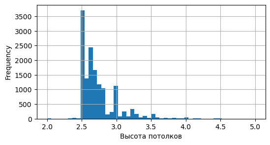

```python
plt.xlabel('Высота потолков')
data['ceiling_height'].plot(kind='hist',bins=50,range=(2,5),grid=True);
```

- Распределение неравномерное, в основном торгуется жильё с потолками 2,5-2,8м. Спад на 2,9м и относительный пик на 3,0м. Далее идёт неравномерное убывание, после 4,5м предложений практически нет.

#### Этаж квартиры.

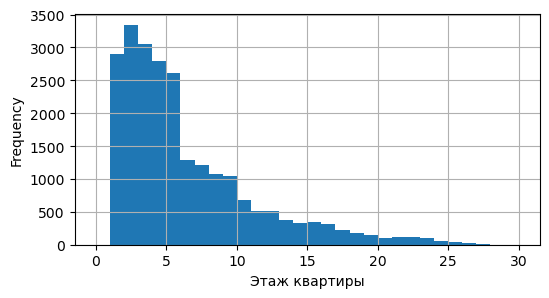

```python
plt.xlabel('Этаж квартиры')
data['floor'].plot(kind='hist',bins=30,range=(0,30),grid=True);
```

#### Распределение по типам этажности квартир.

```
             count
floor_type
1-первый      2903
2-другой     17308
3-последний   3328
```

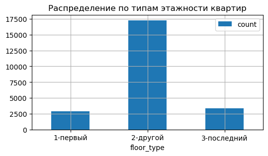

```python
# выводим на график предварительно сгруппированные и посчитанные данные

graph = data.groupby('floor_type')['floor_type'].agg(['count'])
print(graph)
graph.plot(kind='bar',grid=True)
plt.xticks(rotation = 0)
plt.title('Распределение по типам этажности квартир');
```

- Промежуточные этажи встречаются в объявлениях чаще всего. Интересно, что последние этажи опережают первые. Т.е. многоэтажек настолько много, что одноэтажки ничего в статистике не меняют. (Если бы одноэтажные застройки преобладали, ситуация была бы иной)

#### Этажность домов.

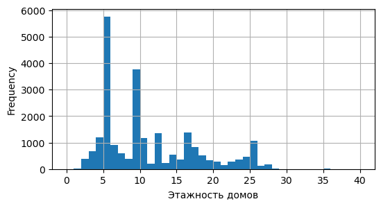

```python
plt.xlabel('Этажность домов')
data['floors_total'].plot(kind='hist',bins=40,range=(0,40),grid=True);
```

- Традиционные 5 (лидер) и 9 этажей прогнозируемо выделяются пиками, поменьше пики для 12-, 16- и 25-этажек, которых примерно поровну и около 1/4 от 5-этажек. На 28-ми этажах практически всё заканчивается, дальше лишь один дом на 35 этажей.

#### Расстояние до центра города в метрах.

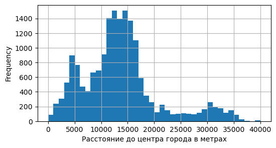

```python
plt.xlabel('Расстояние до центра города в метрах')
data['cityCenters_nearest'].plot(kind='hist',bins=40,range=(0,40000),grid=True);
```

- На представленной гистограмме наблюдается умеренный пик в районе 5км, спад на 7км и максимум в интервале 11-15км. За резким спадом наблюдается небольшое повышение в интервале 30-35км.

#### Расстояние до ближайшего аэропорта.

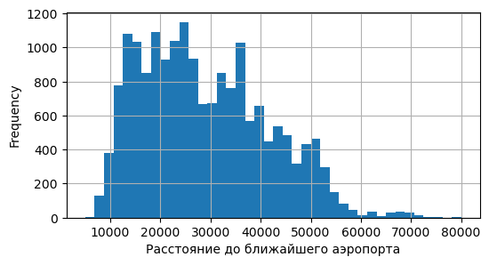

```python
plt.xlabel('Расстояние до ближайшего аэропорта')
data['airports_nearest'].plot(kind='hist',bins=40,range=(5000,80000),grid=True);
```

- Несмотря на биения, у гистограммы выраженный горб в районе 20-25км, центр распределения смещён влево, расстояния более 60км практически не встречаются. Ближе 5км к аэропорту объектов практически нет. Наблюдается аномальный пик в районе 35км, ради интереса проанализируем, что это (см. код ниже)... это Санкт-Петербург, не область.

```python
# фильтруем названия населённых пунктов в 34-36км от аэропорта

data.query('34000  < airports_nearest < 36000').groupby('locality_name')['locality_name'].count()
```

```
locality_name
Петергоф             27
Санкт-Петербург     850
поселок Саперный      6
Name: locality_name, dtype: int64
```

#### Расстояние до ближайшего парка.

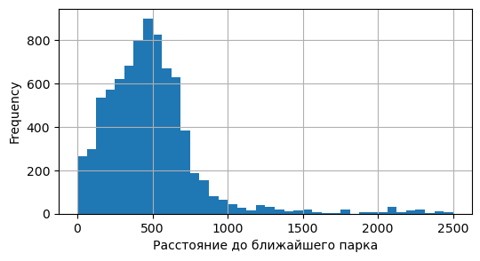

```python
plt.xlabel('Расстояние до ближайшего парка')
data['parks_nearest'].plot(kind='hist',bins=40,range=(0,2500),grid=True);
```

- Неплохо. Много объектов рядом с парком, максимум графика приходится на 500м. После полутора тысяч метров объектов чрезвычайно мало. Этот параметр интересно было бы сопоставить с другими крупными городами мира. Также стоило бы разобраться, что такое "парк" в Яндекс-картах (какая зелёная площадь уже считается парком).

#### День публикации объявления.

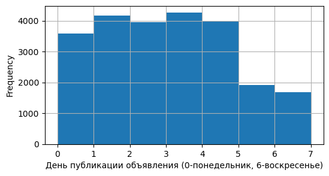

```python
plt.xlabel('День публикации объявления (0-понедельник, 6-воскресенье)')
data['week_day'].plot(kind='hist',bins=7,range=(0,7),grid=True);
```

- В выходные объявлений подаётся вдвое меньше, чем на неделе. Небольшие подъёмы подач во вторник и в четверг.

### Показатели, связанные с продажами.

#### Длительность нахождения квартиры в продаже, дни.

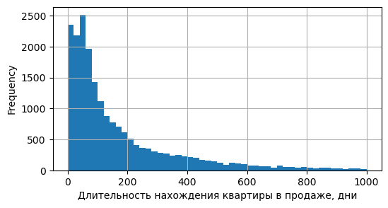

```python
plt.xlabel('Длительность нахождения квартиры в продаже, дни')
data['days_exposition'].plot(kind='hist',bins=50,range=(0,1000),grid=True);
```

```python
print('Среднее -', round(data['days_exposition'].mean()),',' \
      '  Медиана -', round(data['days_exposition'].median()))
```

```
Среднее - 181 ,  Медиана - 95
```

#### Матрица корреляции по выборочным колонкам.

```python
# Выделим в отдельный датафрейм столбцы, по которым будем вести анализ для матрицы корреляции

df = data[['last_price','total_area','living_area','kitchen_area','rooms'\
           ,'floor_type','week_day','month','year',]]
```

```python
# Построим корреляционную матрицу по новому датафрейму

corr_matrix = df.corr()
corr_matrix.style.background_gradient(cmap='coolwarm')
```

|  | last_price | total_area | living_area | kitchen_area | rooms | week_day | month | year |
| --- | --- | --- | --- | --- | --- | --- | --- | --- |
| last_price | 1.000000 | 0.653792 | 0.567472 | 0.521775 | 0.363748 | 0.001580 | 0.002391 | -0.042405 |
| total_area | 0.653792 | 1.000000 | 0.940686 | 0.611436 | 0.759090 | -0.005525 | 0.005035 | -0.078845 |
| living_area | 0.567472 | 0.940686 | 1.000000 | 0.432377 | 0.847590 | -0.006415 | -0.002584 | -0.071646 |
| kitchen_area | 0.521775 | 0.611436 | 0.432377 | 1.000000 | 0.272257 | -0.008134 | 0.003011 | -0.054386 |
| rooms | 0.363748 | 0.759090 | 0.847590 | 0.272257 | 1.000000 | -0.005089 | -0.003318 | -0.054359 |
| week_day | 0.001580 | -0.005525 | -0.006415 | -0.008134 | -0.005089 | 1.000000 | 0.012043 | -0.002888 |
| month | 0.002391 | 0.005035 | -0.002584 | 0.003011 | -0.003318 | 0.012043 | 1.000000 | -0.271418 |
| year | -0.042405 | -0.078845 | -0.071646 | -0.054386 | -0.054359 | -0.002888 | -0.271418 | 1.000000 |

#### Связь типа этажа и цены объекта.

Для изучения связи типа этажа и цены объекта сгруппируем данные при помощи pivot_table и рассмотрим средние по общей цене продаж, цене 1кв.метра и общей площади.

```python
yyy_1 = data.pivot_table(index='floor_type', values='last_price', aggfunc=['mean','median']).apply(round)
yyy_2 = data.pivot_table(index='floor_type', values='price_1m2', aggfunc=['mean','median']).apply(round)
yyy_3 = data.pivot_table(index='floor_type', values='total_area', aggfunc=['mean','median']).apply(round)

data.pivot_table(index='floor_type',values=['last_price','total_area','price_1m2']\
                 ,aggfunc=['mean','median']).apply(round)
```

| floor_type | mean last_price | mean price_1m2 | mean total_area | median last_price | median price_1m2 | median total_area |
| --- | --- | --- | --- | --- | --- | --- |
| 1-первый | 4804332.0 | 82025.0 | 56.0 | 3900000.0 | 81250.0 | 51.0 |
| 2-другой | 6676184.0 | 103501.0 | 60.0 | 4848500.0 | 98284.0 | 52.0 |
| 3-последний | 7339525.0 | 93114.0 | 65.0 | 4300000.0 | 87737.0 | 53.0 |

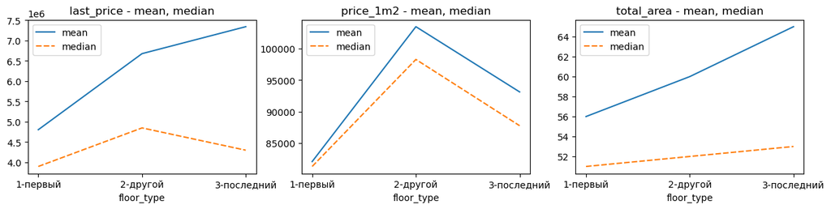

```python
# выведем 3 графика в один контейнер - fig размером 15х3

fig_1 = plt.figure(figsize=(15,3))
ax1 = fig_1.add_subplot(1,3,1)
ax2 = fig_1.add_subplot(1,3,2)
ax3 = fig_1.add_subplot(1,3,3)

sns.lineplot(data=yyy_1, ax=ax1);
sns.lineplot(data=yyy_2, ax=ax2);
sns.lineplot(data=yyy_3, ax=ax3);

ax1.set_title("last_price - mean, median")
ax2.set_title("price_1m2 - mean, median")
ax3.set_title("total_area - mean, median");
```

- Для средних математических значений на последних этажах объекты дороже, на первых - самые дешевые. По цене за квадратный метр последние уступают другим, первые самые дешёвые.
- Для медиан общая цена дороже на средних этажах, а последние уступают.
- Интересно, что с ростом этажности растёт и средняя площадь продаваемых объектов. То есть с поъёмом наверх продажи становятся "более оптовыми".

Посмотрим на зависимость цены продажи от площади объекта, типы этажей подсветим оттенками.

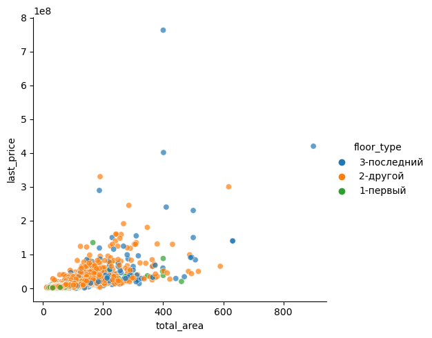

```python
sns.relplot(kind='scatter',x="total_area",y="last_price",data=data,hue="floor_type",\
            hue_order = ['3-последний','2-другой','1-первый'],alpha=0.7);
```

- Действительно, другие и последние этажи перекрывают первые. При этом синие шарики (на то они и последние этажи) летают выше оранжевых (другие этажи). То же самое продемонстрировала и таблица выше - зелёные внизу, как и их этажи, по математическим средним лидируют синие, а по медианам оранжевые (высота парения для медиан не важна, важно количество). **То есть медианы более устойчивы к выбросам**.

#### Зависимость цены от общей площади.

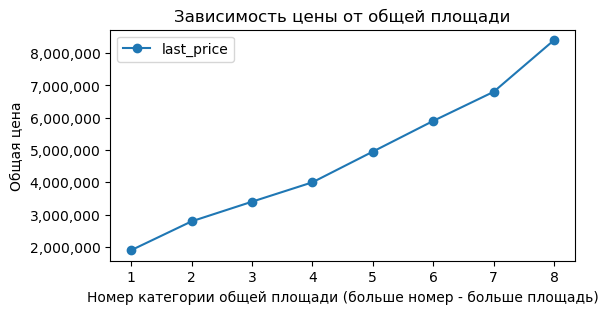

```python
# Для графика "общая площадь - цена" поделим площади на 10 корзин, разрежем массив на 10
# слоёв, сгруппируем их в pivot_table по медианам и сформируем график

area_bins = [0.0, 10.0, 20.0, 30.0, 40.0, 50.0, 60.0, 70.0, 80.0, 90.0]
area_group_names = list(range(9))

data['total_area_group'] = pd.cut(data['total_area'], area_bins, \
                                           labels=area_group_names)

ax = (data
    .pivot_table(index='total_area_group', values='last_price', aggfunc='median')
    .plot(style='o-', title='Зависимость цены от общей площади')
)
ax.get_yaxis().set_major_formatter(
    matplotlib.ticker.FuncFormatter(lambda x, p: format(int(x), ',')))
ax.set(xlabel='Номер категории общей площади (больше номер - больше площадь)', \
       ylabel='Общая цена');
```

- Если до вывода графика данные медианно усреднить по категориям, то получится практически линейная зависимость.

#### Зависимость цены от жилой площади.

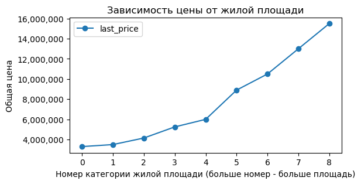

```python
# Для графика "жилая площадь - цена" поделим площади на 10 корзин, разрежем массив на 10
# слоёв, сгруппируем их в pivot_table по медианам и сформируем график

area_bins = [0.0, 10.0, 20.0, 30.0, 40.0, 50.0, 60.0, 70.0, 80.0, 90.0]
area_group_names = list(range(9))

data['living_area_group'] = pd.cut(data['living_area'], area_bins, \
                                           labels=area_group_names)

ax = (data
    .pivot_table(index='living_area_group', values='last_price', aggfunc='median')
    .plot(style='o-', title='Зависимость цены от жилой площади')
)
ax.get_yaxis().set_major_formatter(
    matplotlib.ticker.FuncFormatter(lambda x, p: format(int(x), ',')))
ax.set(xlabel='Номер категории жилой площади (больше номер - больше площадь)', \
       ylabel='Общая цена');
```

- В случае с жилой площадью рост цены до 50кв.м (корзина 40-50) идёт более полого, затем прирост цены за каждый жилой метр больше. То есть более дорогое (и большое) жильё растёт в цене сильнее.

#### Зависимость цены от площади кухни.

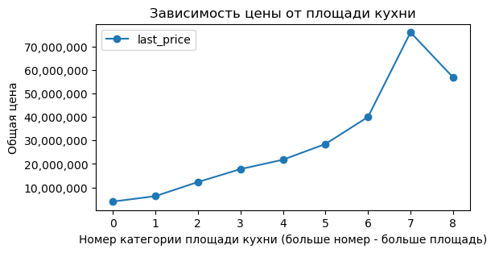

```python
# Для графика "площадь кухни - цена" поделим площади на 10 корзин, разрежем массив на 10
# слоёв, сгруппируем их в pivot_table по медианам и сформируем график

area_bins = [0.0, 10.0, 20.0, 30.0, 40.0, 50.0, 60.0, 70.0, 80.0, 90.0]
area_group_names = list(range(9))

data['kitchen_area_group'] = pd.cut(data['kitchen_area'], area_bins, \
                                           labels=area_group_names)

ax = (data
    .pivot_table(index='kitchen_area_group', values='last_price', aggfunc='median')
    .plot(style='o-', title='Зависимость цены от площади кухни')
)
ax.get_yaxis().set_major_formatter(
    matplotlib.ticker.FuncFormatter(lambda x, p: format(int(x), ',')))
ax.set(xlabel='Номер категории площади кухни (больше номер - больше площадь)', \
       ylabel='Общая цена');
```

```python
# На хвосте графика видно падение, посмотрим количество объектов в этой зоне

data.query('kitchen_area > 40')['kitchen_area'].count(), \
data.query('kitchen_area > 50')['kitchen_area'].count(), \
data.query('kitchen_area > 60')['kitchen_area'].count(), \
data.query('kitchen_area > 70')['kitchen_area'].count(), \
data.query('kitchen_area > 80')['kitchen_area'].count()
```

```
(129, 46, 24, 11, 7)
```

- Для кухонь размером меньше 3-комнатной квартиры (60 кв.м) цена растёт монотонно и предсказуемо, за этим барьером стоимость резко подрастает и также резко падает. По-видимому, эта нестабильность связана с небольшим количеством объектов и "более свободной" компоновкой.

#### Зависимость цены от количества комнат.

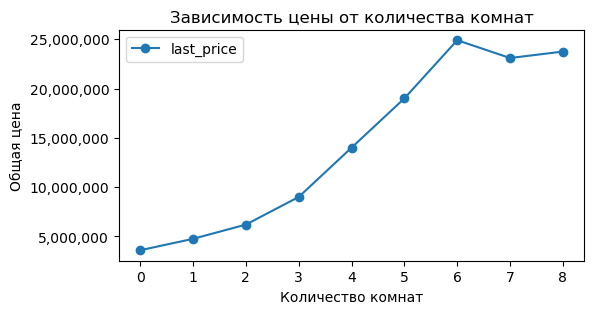

```python
# Для графика "комнаты-цена" поделим комнаты на 10 корзин, разрежем массив на 10
# слоёв, сгруппируем их в pivot_table по медианам и сформируем график

room_bins = [0, 1, 2, 3, 4, 5, 6, 7, 8, 9]
room_group_names = list(range(9))

data['rooms_group'] = pd.cut(data['rooms'], room_bins, \
                                           labels=room_group_names)

ax = (data
    .pivot_table(index='rooms_group', values='last_price', aggfunc='median')
    .plot(style='o-', title='Зависимость цены от количества комнат')
)
ax.get_yaxis().set_major_formatter(
    matplotlib.ticker.FuncFormatter(lambda x, p: format(int(x), ',')))
ax.set(xlabel='Количество комнат', \
       ylabel='Общая цена');
```

#### Средние цены и день недели.

Для отображения зависимости математически и медианно усреднённых цен и дней недели подготовим данные в pivot_table

```python
yyy = data.pivot_table(index='week_day', values='last_price', aggfunc=['mean','median']).apply(round)
yyy
```

| week_day | mean last_price | median last_price |
| --- | --- | --- |
| 0 | 6519655.0 | 4650000.0 |
| 1 | 6377144.0 | 4709190.0 |
| 2 | 6629206.0 | 4700000.0 |
| 3 | 6709726.0 | 4650000.0 |
| 4 | 6362415.0 | 4550000.0 |
| 5 | 6987044.0 | 4550000.0 |
| 6 | 6243634.0 | 4540000.0 |

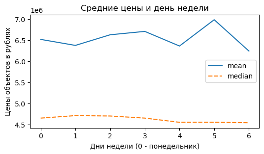

```python
# формируем график с 2-мя линиям с помощью seaborn

sns.lineplot(data=yyy)
plt.title('Средние цены и день недели')
plt.ylabel('Цены объектов в рублях')
plt.xlabel('Дни недели (0 - понедельник)');
```

#### Средние цены и месяц года.

Формируем график "Средние цены и месяц года"

```python
yyy = data.pivot_table(index='month', values='last_price', aggfunc=['mean','median']).apply(round)
yyy
```

| month | mean last_price | median last_price |
| --- | --- | --- |
| 1 | 6665829.0 | 4600000.0 |
| 2 | 6465437.0 | 4650000.0 |
| 3 | 6362418.0 | 4650000.0 |
| 4 | 6745516.0 | 4800000.0 |
| 5 | 6598757.0 | 4500000.0 |
| 6 | 6317466.0 | 4400000.0 |
| 7 | 6636481.0 | 4650000.0 |
| 8 | 6346184.0 | 4565000.0 |
| 9 | 6839228.0 | 4700000.0 |
| 10 | 6239750.0 | 4570000.0 |
| 11 | 6424616.0 | 4700000.0 |
| 12 | 7007209.0 | 4700000.0 |

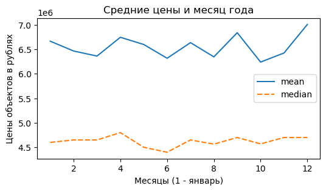

```python
# формируем график с 2-мя линиям с помощью seaborn

sns.lineplot(data=yyy)
plt.title('Средние цены и месяц года')
plt.ylabel('Цены объектов в рублях')
plt.xlabel('Месяцы (1 - январь)');
```

#### Средние цены и годы публикации.

Формируем график "Средние цены и годы публикации"  
(помним, что между публикацией и продажей в среднем проходит 3 месяца)

```python
yyy = data.pivot_table(index='year', values='last_price', aggfunc=['mean','median']).apply(round)
yyy
```

| year | mean last_price | median last_price |
| --- | --- | --- |
| 2014 | 12046600.0 | 7640000.0 |
| 2015 | 8546268.0 | 5300000.0 |
| 2016 | 6834978.0 | 4550000.0 |
| 2017 | 6583949.0 | 4500000.0 |
| 2018 | 5954717.0 | 4550000.0 |
| 2019 | 6780487.0 | 5050000.0 |

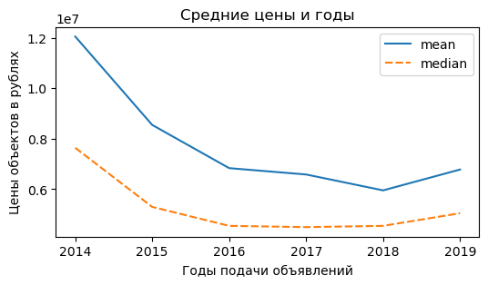

```python
# формируем график с 2-мя линиям с помощью seaborn

sns.lineplot(data=yyy)
plt.title('Средние цены и годы')
plt.ylabel('Цены объектов в рублях')
plt.xlabel('Годы подачи объявлений');
```

- Цены после 2014-го за 3 года просели в 1,5 (можно сказать в 2) раза, через 5 лет они демонстрируют тенденцию к небольшому росту.

#### 1 кв.м жилья в нас. пунктах лидерах по объявлениям.

Сформируем график "Стоимость 1 кв.м жилья в 10 населённых пунктах с наибольшим количеством объявлений"

```python
# Отсортируем данные методом groupby, посчитаем среднюю медианную цену и количество

graph_10 = data.groupby('locality_name')['price_1m2'].agg(['count','median'])\
.sort_values('count',ascending=False).head(10).apply(round)
display(graph_10)
```

| locality_name | count | median |
| --- | --- | --- |
| Санкт-Петербург | 15631 | 104806.0 |
| поселок Мурино | 552 | 86059.0 |
| поселок Шушары | 438 | 76748.0 |
| Всеволожск | 398 | 65789.0 |
| Пушкин | 369 | 100000.0 |
| Колпино | 338 | 74724.0 |
| поселок Парголово | 327 | 91643.0 |
| Гатчина | 306 | 67861.0 |
| деревня Кудрово | 299 | 91860.0 |
| Выборг | 237 | 58158.0 |

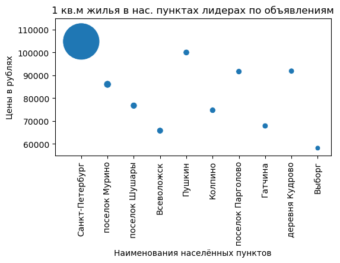

```python
# Из полученной таблицы выделим оси, в том числе для размера "шаров" на графике

plt.rcParams['figure.figsize'] = [6, 3]
a3 = graph_10['count'].values
a1 = graph_10['median'].values
a2 = graph_10['count'].index
sns.scatterplot(x=a2, y=a1, size=a3, legend=False, sizes=(40, 2000)) # график и его параметры
plt.xticks(rotation = 90)
plt.xlim(-1, 9.5)
plt.ylim(55000, 115000)
plt.title('1 кв.м жилья в нас. пунктах лидерах по объявлениям')
plt.ylabel('Цены в рублях')
plt.xlabel('Наименования населённых пунктов');
```

- Количество объявлений в СПб намного больше объявлений в других городах, поэтому размеры шаров в других 9-ти городах малоконтрастны. Медианная цена в Санкт-Петербурге 104800 (наиболее дорогой город), а в Выборге она для нашей десятки минимальна - 58158.

#### 1 кв.м жилья в 10 лидерах по цене.

```python
# Отсортируем данные методом groupby, посчитаем среднюю (арифметическую) цену и количество
graph_11 = data.groupby('locality_name')['price_1m2'].agg(['count','mean'])\
.sort_values('mean',ascending=False).head(10)
display(graph_11)
```

| locality_name | count | mean |
| --- | --- | --- |
| Зеленогорск | 24 | 115122.799198 |
| Санкт-Петербург | 15631 | 114841.824304 |
| поселок Репино | 4 | 104238.614786 |
| Пушкин | 369 | 103125.819291 |
| Сестрорецк | 183 | 101757.616875 |
| поселок Лисий Нос | 3 | 100660.814239 |
| Кудрово | 171 | 100134.543715 |
| деревня Мистолово | 11 | 98549.976709 |
| поселок Левашово | 1 | 96997.690531 |
| Мурино | 34 | 92722.708914 |

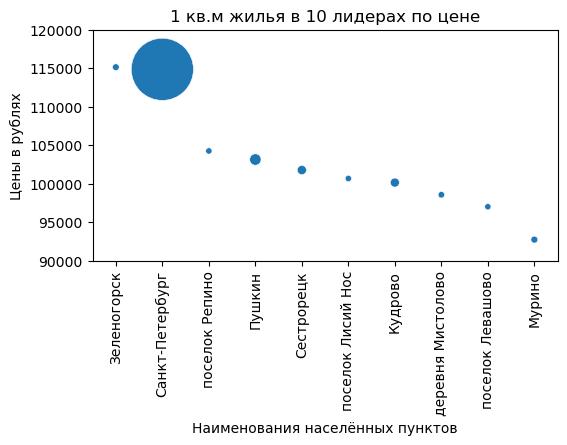

```python
# Из полученной таблицы выделим оси, в том числе для размера "шаров" на графике

a3 = graph_11['count'].values
a1 = graph_11['mean'].values
a2 = graph_11['count'].index
sns.scatterplot(x=a2, y=a1, size=a3, legend=False, sizes=(20, 2000)) # график и его параметры
plt.xticks(rotation = 90)
plt.xlim(-0.5, 9.5)
plt.ylim(90000, 120000)
plt.title('1 кв.м жилья в 10 лидерах по цене')
plt.ylabel('Цены в рублях')
plt.xlabel('Наименования населённых пунктов');
```

- Как видно из графика, больше всего объявлений в Санкт-Петербурге (2-е место по стомости 1 кв. метра),
- но цена за квадратный метр в нём не так высока, как в Зеленогорске (1-е место) - 115123руб за метр (кстати, выше уже упоминалось о высокой доступности парковых зон в целом по рынку Ленинградской области).
- С ценой 92722руб за метр Мурино (10-е место) замыкает рейтинг самых дорогих населённых пунктов.

#### Цена 1 кв.м в зависимости от расстояния до центра.

Сформируем график "Цена 1 кв.м в зависимости от расстояния до центра". Для этого сгруппируем данные для Санкт-Петербурга пошагово для расстояний от центра кратно 1км

```python
# создаём набор данных (таблицу) graph_29, по которой будем рисовать график

graph_9 = data.query('locality_name == "Санкт-Петербург"').groupby('center_dist')\
['price_1m2'].agg(['count','mean'])
display(graph_9.tail())
```

| center_dist | count | mean |
| --- | --- | --- |
| 25.0 | 26 | 91531.371618 |
| 26.0 | 43 | 87798.872892 |
| 27.0 | 2 | 132115.709459 |
| 28.0 | 7 | 81161.915320 |
| 29.0 | 6 | 72953.365445 |

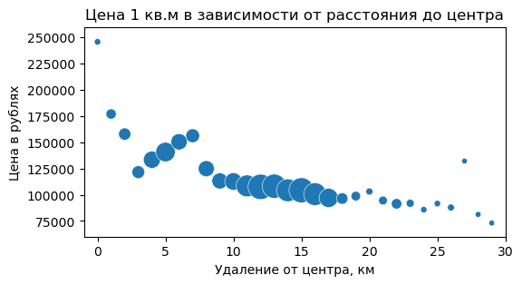

```python
# Из полученной таблицы выделим оси, в т.ч. количества объявлений для размера "шаров"

dist = graph_9.index
price = graph_9['mean'].values
vol = graph_9['count'].values
sns.scatterplot(x=dist,y=price,size=vol,legend=False,sizes=(20,400)) # график и его параметры
plt.xlim(-1, 30)
plt.ylim(60000, 260000)
plt.title('Цена 1 кв.м в зависимости от расстояния до центра')
plt.ylabel('Цена в рублях')
plt.xlabel('Удаление от центра, км');
```

- Как видно из графика, убывание средней цены 1кв.м. в Санкт-Петербурге при удалении от центра немонотонно: в интервале 3-7км цены даже растут, а не падают (удорожание 1 кв.м составляет +8660руб/км). Удешевление 1 кв.м в интервале 8-29км составляет 1320руб/км.
- В районе 27км тоже есть пик, но количество объявлений там небольшое, по большей части торгуется жильё на дистанции 2-17км от центра. На удалении от центра около 30км цена падает почти в 3,4 раза.
- Аномальность поведения цены в интервале 3-7км (для непетербуржца) требует дополнительных исследований, уже без кругового усреднения.

Ниже посчитаны удорожания и удешевления средней стоимости 1кв.м в интервалах 3-7км и 8-29км от центра.

```python
fit_3_7 = np.polyfit(list(graph_9.index)[3:8], list(graph_9['mean'][3:7]),1)
fit_8_29 = np.polyfit(list(graph_9.index)[8:30], list(graph_9['mean'][8:29]),1)
fit_3_7, fit_8_29
```

```
(array([ 8661.85556282, 97163.22670989]),
 array([ -1321.73732993, 124798.37660572]))
```